# DATA 550 Lab 3 - Communication visualizations

There are two versions of this lab, one in Python and one in R. The R lab will use `ggplot` and the Python lab will use `Altair`.

This is the Python version.

Each partner should choose a version to complete, though keep in mind that **you are required to alternate between completing the R labs and the Python labs** to get experience using both languages.

## Acknowledgemnts

This lab was lightly adapted from the one created by Joel Ostblom for the DSCI 531 version of Data Viz I in the 2020/21 Academic year.

## Submission instructions rubric={mechanics:2}

You receive marks for submitting your lab correctly, please follow these instructions:

- Each partner should complete one file, though collaboration is permitted.
- Push your `.ipynb` files to GitHub frequently (i.e. not just in one fell swoop at the end).
- Don't forget to submit a clickable link to your GitHub repo on Canvas so we can grade it.

```python
# Run this cell to ensure that altair plots show up in the exported HTML
# and that the R cell magic works
import altair as alt

# Save a vega-lite spec and a PNG blob for each plot in the notebook
alt.renderers.enable('mimetype')
# Handle large data sets without embedding them in the notebook
alt.data_transformers.enable('data_server')
```

```
DataTransformerRegistry.enable('data_server')
```

## 0. So we meet again...

I am sure you have heard, turns out Bestflix did not make it. Copyright issues they said, can you believe it?? I can't, there must have been more to this story... And the only other person with knowledge of this enterprise was... YOU!

In the spirit of a true comic book criminal, I will scale my revenge for this set back completely out of proportion and attempt world dominion. Don't worry, there will be no blood shed, I operate with class so my plan here is to brainwash people into thinking that I am actually good for them and then reap personal benefits once in power, creative isn't it?

To convince the pleb... I mean honorary citizens of the world to vote for me, I have made several key visualizations showing what an ideal candidate I am. The only way to stop me (hmm why am I telling you this again...) is to debunk these visualizations and show voters the errors of my ways (this is clearly a fictional scenario since we are assuming that each person acts rationally and is convinced by data).

Below is my publicly distributed campaign material covering these four main area:

1. The current dramatic increase in job dissatisfaction
2. My previous record on increasing job wages for all
3. Guns to the people
4. My great approval rating

For each figure that I have made, I have also included the underlying data (imagine what a wonderful world it would be if that actually happened in real life...). You can find these datasets in your lab repo). For each question in this lab, your team has the following three tasks:

1. Decide if you think my plot and my claim is misleading or not, why you think so, and how you would improve it in your version of the same figure (unless you think mine is already good). In addition to what we are learning this week, you will need to draw on your knowledge from last week for when certain plots are suitable and which are common pitfalls to avoid.
2. To earn the people's trust, you need to recreate my plot to show that you know what I did. This includes axis labels, legends, colors, titles, figure size, everything as close as possible to the images I have pasted for each question below.
3. Create your own better version of the same figure. Make sure that your choices are motivated in writing in point 1.

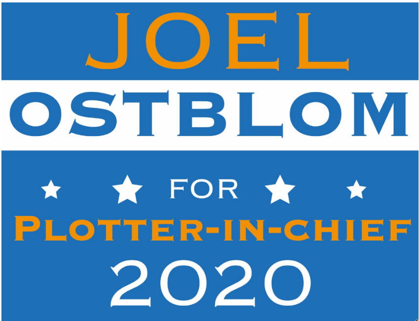

*Full credit to my lab colleague who would like to remain unnamed but made this for me earlier in the year.*

# 1. Dramatic decline in job satisfaction

## The data

The `cities-job-satisfaction.csv` dataset contains (fictional) data from different cities around the world. In this data it was measured which proportion of people reported that they were unsatisfied with their work situation this year compared to last year. Each data point is a different city, and the value indicates the proportion of dissatisfied workers.

## My plot

### Altair

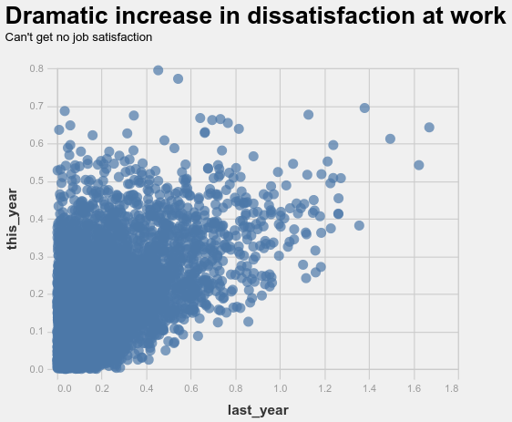

## My claim

You can clearly see in this plot that people are dramatically more dissatisfied at work this year compared to last year. I have used transparency for the dots to prevent overplotting/oversaturation, so this means that the entire dark area has an even amount of cities throughout. In other words, there are as many cities that increased from ~0% to ~40% dissatisfaction as there are cities that stayed around 0%. That's atrocious! Vote Ostblom in 2020 and I will end this spiral before it is too late!

### Question 1.1 rubric={reasoning:2,writing:1}

- Explain which mistakes (if any) I have done in my plot and provide an interpretation of the data that is more correct than mine. Be brief and clear in your answer.
- You might have some ideas just from looking at my plot, but you will likely need to do some investigation yourself to answer this question fully. You can reference your improved plot as needed.

YOUR ANSWER HERE

Due to the high number of plots, I would say that overplotting is still an issue here. Even with point transparency, we cannot differentiate the number of data points in the bottom left area of the graph (the solid blue area), so it looks like your claim is accurate (even though it is not), and we assume that all areas that look solid blue are the same when they are not. The 2D histogram solves this problem and allows you to see the true distribution of the data. We can see that the claim of "there are as many cities that increased from ~0% to ~40% dissatisfaction as there are cities that stayed around 0%" is false because the colors of those bins that were referenced are drastically different in the 2D histogram.

Other issues:

- Axes are labelled with column names (not titles).
- Title pushes your opinion and inference from the graph, instead of simply describing what the graph is displaying.
- The x and y axis spacing should be the same since the units are the same for both axis. It is confusing to compare last year to this year when the axes don't match on the tick marks. There also appears to be proportions for `last_year` that are greater than 1.0, which means greater than 100% which is impossible. Cities containing this kind of data should be dropped from the dataset.
- The subtitle is not adding any information.

Additional interpretation:

I wanted to see the change in job dissatisfaction rates in cities from year to year, and I find it difficult to compare the years as a whole in this style of graph, so I also decided to plot the density distribution of the rates for each year. I marked the mean of each year's rates on the plot to give a clear indication of which year had, on average, higher job dissatisfaction rates. This plot actually refutes your claim and shows that the average job dissatisfaction rate was higher last year compared to this year. I also ended up making a jitter plot of the data separated by year and it shows that more cities had higher job dissatisfaction rate last year compared to last year.

### Question 1.2 rubric={accuracy:2}

#### Python

Recreate the Altair version of the plot. Your plot should look as close as possible to mine in the image above.

```python
import pandas as pd
```

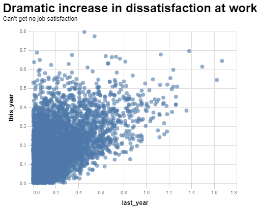

```python
# YOUR ANSWER HERE
jobs_df = pd.read_csv('cities-job-satisfaction.csv')

ex_chart = alt.Chart(jobs_df, title=alt.TitleParams(text="Dramatic increase in dissatisfaction at work",
                    subtitle="Can't get no job satisfaction",fontSize=24, align='left', anchor='start', dy=-10, dx=-10, subtitleFontSize=12)
                    ).mark_circle(size=60, opacity = 0.6).encode(
    alt.X('last_year'),
    alt.Y('this_year')).configure_axis(titleFontSize=12, labelFontSize=9, labelPadding=4,
                                       labelColor='grey', titlePadding=10, tickSize=10, tickColor='grey', tickOpacity=0.4, domain=False)
ex_chart
```

### Question 1.3 rubric={viz:2}

#### Python

Improve my Altair plot. Chose the best type of plot to accurately reveal what the data looks like. Design the plot to be an effective plot for communication purposes, this includes proper figure size, axis/figure titles, font sizes, colors, etc.

```python
jobs_df.rename(columns={'last_year': 'Last Year', 'this_year': 'This Year'}, inplace=True)
```

```python
jobs_df['This Year'].count()
```

```
4495
```

```python
# Check for non-realistic job dissatisfaction rates. You can't have a proportion of a population greater than 1.0, so we
# will drop all rows that contain values > 1.0
jobs_df[jobs_df > 1.0].count()
```

```
Last Year    44
This Year     0
dtype: int64
```

We can see that there are 44 entries in the `last year` column that have impossible proportions (> 1.0). We will drop those rows from the dataframe below.

```python
# Drop rows with innacurate proportions.
jobs_df.drop(jobs_df[jobs_df['Last Year'] > 1.0].index, inplace=True)
# Confirm proportions have been corrected.
jobs_df[jobs_df > 1.0].count()
```

```
Last Year    0
This Year    0
dtype: int64
```

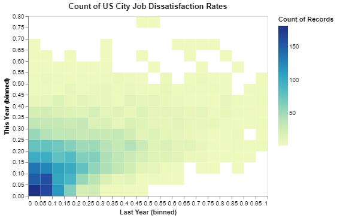

```python
#THIS IS THE ONE TO USE, add the other one for information.

alt.Chart(jobs_df, title=alt.TitleParams(text='Count of US City Job Dissatisfaction Rates')).mark_rect().encode(
    alt.X('Last Year', bin=alt.Bin(maxbins=40), axis=alt.Axis(format='~s')),
    alt.Y('This Year', bin=alt.Bin(maxbins=30)),
    alt.Color('count()'))
```

```python
# Wrangling the data for the plots below so we can plot by year.
jobs_df.head()
jobs_stacked = pd.DataFrame(jobs_df.stack())
jobs_stacked = jobs_stacked.reset_index()
jobs_stacked.drop('level_0', axis=1, inplace=True)
jobs_stacked.rename(columns= {'level_1': 'Year', 0:'Value'}, inplace=True)
```

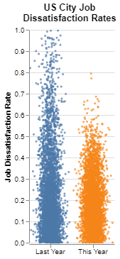

```python
stripplot = alt.Chart(jobs_stacked, width=60).mark_circle(size=8).encode(
    x=alt.X(
        'jitter:Q',
        title=None,
        axis=alt.Axis(ticks=True, grid=False, labels=False),
        scale=alt.Scale(),
    ),
    y=alt.Y('Value:Q', title='Job Dissatisfaction Rate'),
    color=alt.Color('Year', legend=None),
    column=alt.Column(
        'Year',
        header=alt.Header(
            labelAngle=0,
            titleOrient='top',
            labelOrient='bottom',
            labelAlign='center',
            labelPadding=10,
            title=None
        ),
    ),
).transform_calculate(jitter='sqrt(-2*log(random()))*cos(2*PI*random())'
).configure_facet(
    spacing=0
).configure_view(
    stroke=None
)
stripplot.title= alt.TitleParams(text=['US City Job', 'Dissatisfaction Rates'], anchor='middle', dx=15)

stripplot
```

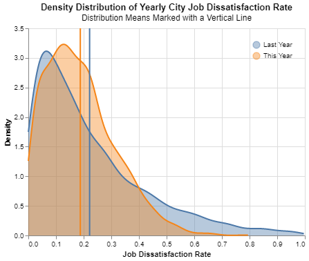

```python
area = alt.Chart(jobs_stacked).transform_density(
    'Value', groupby=['Year'], as_=['Value', 'density'], steps=200).mark_area(opacity=0.4).encode(
    alt.X('Value', title='Job Dissatisfaction Rate'),
    alt.Y('density:Q', title='Density'),
    alt.Color('Year', legend=alt.Legend(orient='top-right', title=None)))

line = alt.Chart(jobs_stacked).transform_density(
    'Value', groupby=['Year'], as_=['Value', 'density'],
    steps=200).mark_line().encode(
    alt.X('Value'),
    alt.Y('density:Q'),
    alt.Color('Year'))

mean = alt.Chart(jobs_stacked).mark_rule().encode(
    x='mean(Value):Q',
    size=alt.value(2), color='Year')

Density =  area + line + mean
Density.title= alt.TitleParams(text='Density Distribution of Yearly City Job Dissatisfaction Rate',
                              subtitle="Distribution Means Marked with a Vertical Line")

Density
```

# 2. I will keep raising wages for all

## The data

The `wages.csv` dataset contains (fictional) data from different companies in the city where I have been the mayor for the last few years. Each datapoint represents the average salary at a company. All the major companies in this city were surveyed both before I was elected and after a few years of my governing. However, this is not paired data, some companies are different from "before" and "after", so you do not need to do a paired analysis.

## My plots

### Altair

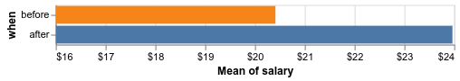

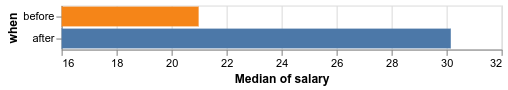

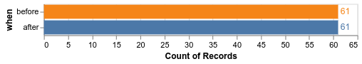

## My claim

As you can see, I have been able to produce a significant increase in the average salary for workers in my city. This high raise almost certainly entails that all (or almost all) workers are receiving a higher payment than what they were before I started to govern. But since I know you are going to ask me for more robust estimates, I have also provided the median increase (which is even more notable) and the number of workers in each group (so that you can see that the samples are balanced). Vote Ostblom in 2020 and there will be higher salaries for all workers!

### Question 2.1 rubric={reasoning:2,writing:1}

- Explain which mistakes (if any) I have done in my plot and provide an interpretation of the data that is more correct than mine. Be brief and clear in your answer.
- You might have some ideas just from looking at my plot, but you will likely need to do some investigation yourself to answer this question fully. You can reference your improved plot as needed.

YOUR ANSWER HERE

There are two main issues here:

1. The x axis is truncated (does not start at 0), so the difference between the two categories is exaggerated for the `median` and `mean` charts. This violates the principle of "proportional ink". When the x-axis starts at 0 (as seen in the `mean` chart I made), the difference between the two time periods seems less drastic.
2. Only displaying the mean, median, and total count of the data hides the true distribution of the data. As seen on the strip plot I made, the true story of the data is quite different than what you would expect after looking at the mean and median only. We see that after mayor Ostblom was voted in, almost half of companies average salaries increased substantially, and the other half decreased substantially. This refutes the claim that "all (or almost all) workers are receiving a higher payment than what they were before [Ostblom] started to govern." Even though the average and median increased after Ostblom was voted in, there is a large section of employees in his city who had their salaries decreased once he took power. This may be due to policies that benefit some companies and hinder others.

Other minor issues:

- Lack of title and lack of descriptive axis titles/labels that explain what the graph is showing. "when" does not tell you enough information.
- The number "61" on top of the bars in the `count` graph should be in black for better readability.

### Question 2.2 rubric={accuracy:2}

#### Python

Recreate the Altair versions of my three plots in one cell each. Your plots should look as close as possible to mine in the images above.

```python
wages_df = pd.read_csv('wages.csv')
```

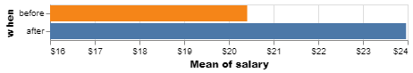

```python
# YOUR ANSWER HERE
mean_sal = alt.Chart(wages_df).mark_bar().encode(
alt.X('mean(salary)', scale=alt.Scale(domain=(16,24)),
     axis=alt.Axis(format='$~s')), alt.Y('when', sort='x'), color=alt.Color('when', legend=None)).configure_axis(
    titleFontWeight=800)

mean_sal
```

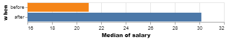

```python
# YOUR ANSWER HERE
med_sal = alt.Chart(wages_df).mark_bar().encode(
alt.X('median(salary)', scale=alt.Scale(domain=(16,32))), alt.Y('when', sort='x'), color=alt.Color('when', legend=None)).configure_axis(
    titleFontWeight=800)

med_sal
```

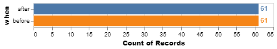

```python
# YOUR ANSWER HERE
count_sal = alt.Chart(wages_df).mark_bar().encode(
alt.X('count()'), alt.Y('when', sort='x'), color=alt.Color('when', legend=None))#

new = count_sal + count_sal.mark_text(dx=9).encode(text='count()')
new_bold = new.configure_axis(titleFontWeight=800)
new_bold
```

### Question 2.3 rubric={viz:2}

#### Python

Improve my Altair plots. Chose the best type of plot to accurately reveal what the data looks like. Design the plot to be an effective plot for communication purposes, this includes proper figure size, axis/figure titles, font sizes, colors, etc. You can either make a single or several plots, depending on what you think is needed.

```python
# changing string values to allow proper legend labels.
wages_w = wages_df
wages_w['when'] = wages_w['when'].map(lambda x: x.capitalize() + ' Mayor Ostblom')
```

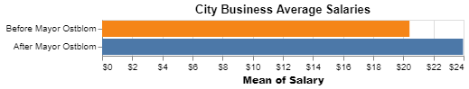

```python
# show mean of salary chart with proper axis values.
mean_sal_true = alt.Chart(wages_w, title=alt.TitleParams(text="City Business Average Salaries")).mark_bar().encode(
alt.X('mean(salary)', title='Mean of Salary',
     axis=alt.Axis(format='$~s')), alt.Y('when', title= None, sort='x'), color=alt.Color('when', legend=None)).configure_axis(
    titleFontWeight=800)

mean_sal_true
```

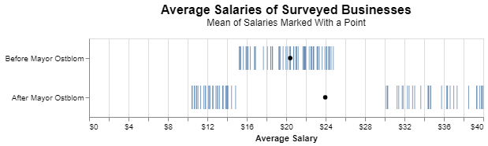

```python
sal_tick = alt.Chart(wages_w, title=alt.TitleParams(text="Average Salaries of Surveyed Businesses", fontSize=16,
                                                   subtitle='Mean of Salaries Marked With a Point', dy=-10)).mark_tick(size=30).encode(
alt.X('salary', title='Average Salary',
     axis=alt.Axis(format='$~s')), alt.Y('when', title= None, sort='descending'))

sal_tick

sal_tick_mean = sal_tick + sal_tick.mark_point(color='black', filled=True).encode(alt.X('mean(salary)'))

sal_tick_mean.properties(height=100, width=500)
```

# 3. Guns to the people

## My plots

### Altair

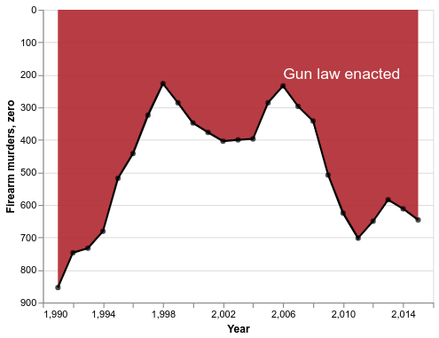

## My claim

As you can see, just after the gun law in Florida was enacted, deaths from firearms plummeted. I don't really think there is much else to discuss here. Do you want a gun **and** less firearm-related deaths? Vote Ostblom in 2020!

### Question 3.1 rubric={reasoning:2,writing:1}

- Explain which mistakes (if any) I have done in my plot and provide an interpretation of the data that is more correct than mine. Be brief and clear in your answer.
- You might have some ideas just from looking at my plot, but you will likely need to do some investigation yourself to answer this question fully. You can reference your improved plot as needed.

YOUR ANSWER HERE

We are used to thinking that if a line moves down on the y-axis, the value is decreasing. The main issue here is that the Y axis is reversed, so as the line moves down, the value is actually increasing. The claim is wrong because it is stating that after the gun law was enacted, that gun related deaths decreased. If you read the scale properly, you will see that gun related deaths reversed their overall trend of decreasing and started to increase after the gun law was enacted.

Other minor issues are:

- Missing title (we don't know what sample population the data is representing).
- Year axis tick labels have commas (it is a year, not an integer).
- Y-axis label should not have the ", zero" in it.
- The red color is misleading. It may have been intentionally chosen to represent blood so it looked like less murders/blood was happening after the gun law was enacted. I would remove the color to avoid this distraction.

### Question 3.2 rubric={accuracy:2}

#### Python

Recreate the Altair version of the plot. Your plot should look as close as possible to mine in the image above.

```python
gun_df = pd.read_csv('guns-r-us.csv')
gun_df.head()
```

|  | Year | Firearm murders |
| --- | --- | --- |
| 0 | 1991 | 854 |
| 1 | 1992 | 747 |
| 2 | 1993 | 733 |
| 3 | 1994 | 681 |
| 4 | 1995 | 518 |

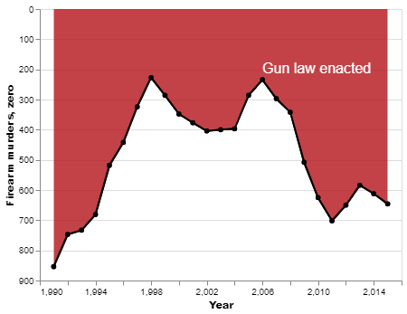

```python
# YOUR ANSWER HERE
bad_chart = alt.Chart(gun_df).mark_line(color='black',
                        point=alt.OverlayMarkDef(filled=True, fill='black')).encode(
    alt.X('Year', scale=alt.Scale(zero=False), axis=alt.Axis(grid=False)),
    alt.Y('Firearm murders', scale=alt.Scale(reverse=True), title='Firearm murders, zero'))

new_bad = bad_chart + bad_chart.mark_area(color='#b41319', opacity=0.8,
    line=alt.OverlayMarkDef(color='black'), point=alt.OverlayMarkDef(color='black'))

new_text = new_bad + alt.Chart(gun_df.query('Year == 2006')).mark_text(dy=-12, dx=60).encode(
    alt.X('Year'),
    alt.Y('Firearm murders'),
    text=alt.value('Gun law enacted'),
    size=alt.value(16), color=alt.value('white'))

new_text.configure_axis(titleFontWeight=800)
```

### Question 3.3 rubric={viz:2}

#### Python

Improve my Altair plot. Chose the best type of plot to accurately reveal what the data looks like. Design the plot to be an effective plot for communication purposes, this includes proper figure size, axis/figure titles, font sizes, colors, etc.

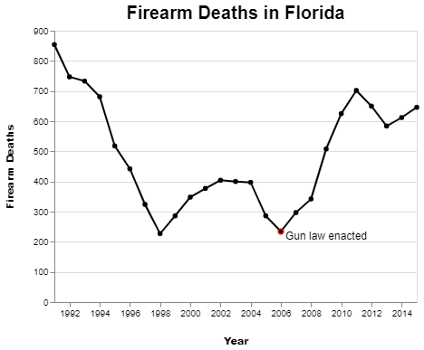

```python
# YOUR ANSWER HERE
# Change year to datetime to fix axis labels in chart
gun_df['Year'] = pd.to_datetime(gun_df['Year'], format='%Y')

good_chart = alt.Chart(gun_df, title=alt.TitleParams(text="Firearm Deaths in Florida", fontSize=20)).mark_line(color='black',
                        point=alt.OverlayMarkDef(filled=True, fill='black')).encode(
    alt.X('Year', axis=alt.Axis(grid=False, formatType='time', format='%Y')),
    alt.Y('Firearm murders', title='Firearm Deaths'))

# Add text to point where gun law enacted.
new_text = good_chart + alt.Chart(gun_df.query('Year == 2006')).mark_text(dy=5, dx=50).encode(
    alt.X('Year'),
    alt.Y('Firearm murders'),
    text=alt.value('Gun law enacted'),
    size=alt.value(12), color=alt.value('black'))

# Highlight dot where new law was enacted (the first chart says 2005, but yours looks like 2006 so I chose 2006)
new_dot = new_text + alt.Chart(gun_df.query('Year == 2006')).mark_point().encode(
    alt.X('Year'),
    alt.Y('Firearm murders'),
    color=alt.value('red'))

new_dot.configure_axis(titleFontWeight=800, titlePadding=20)
```

# My approval ratings are astronomical

## The data

The (fictional) `state-comparison.csv` dataset contains a sample of voters from my state and a neighboring state of similar socioeconomic standard. Voters in each state were asked to rate their approval of the state's mayor on a scale from 0 - 10,000.

## My plots

### Altair

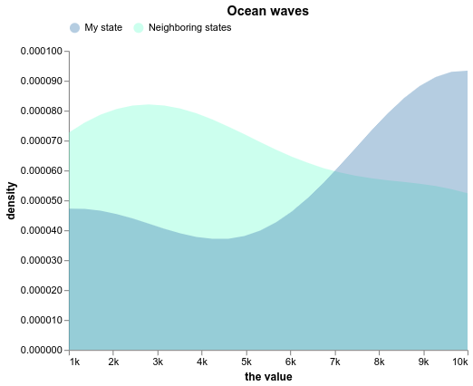

## My claim

My approval ratings are through the roof! I am clearly doing a better job than my colleague and competitor next doors. And as you can see we sampled enough people to get smooth curves, which means that this difference is both likely to be statistically significant and the magnitude is just too big to ignore. There seems to be a few bores on the lower end of the spectrum, but can't win them all I guess. Do you want a 10k approval rating future? Vote Ostblom in 2020!

### Question 4.1 rubric={reasoning:2,writing:1}

- Explain which mistakes (if any) I have done in my plot and provide an interpretation of the data that is more correct than mine. Be brief and clear in your answer.
- You might have some ideas just from looking at my plot, but you will likely need to do some investigation yourself to answer this question fully. You can reference your improved plot as needed.

YOUR ANSWER HERE

The main mistake here is that the plot makes it appear that there is a sufficient amount of data collected to produce a smooth distribution, when in reality, there were only 3 data points collected for each `where` category. With only 3 data points, we cannot get an accurate idea of the distribution of the data over all the ratings.

Other issues:

- The title has nothing to do with the data being displayed
- axis labels are left as the column labels.
- The scale of ratings is unnecessarily large. You lose no accuracy by dividing all the values by 1000 and making it a scale from 1-10.

### Question 4.2 rubric={accuracy:2}

#### Python

Recreate the Altair version of the plot. Your plot should look as close as possible to mine in the image above.

```python
ratings_df = pd.read_csv('state-comparison.csv')
ratings_df
```

|  | where | the value |
| --- | --- | --- |
| 0 | Neighboring states | 1000 |
| 1 | Neighboring states | 4100 |
| 2 | Neighboring states | 10000 |
| 3 | My state | 1000 |
| 4 | My state | 10000 |
| 5 | My state | 9900 |

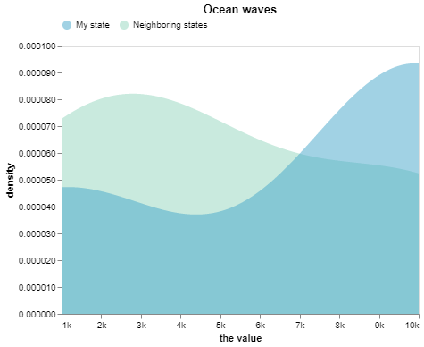

```python
# YOUR ANSWER HERE
area = alt.Chart(ratings_df).transform_density(
    'the value', groupby=['where'], as_=['the value', 'density'], steps=200).mark_area(opacity=0.5).encode(
    x = alt.X('the value', axis = alt.Axis(format='~s', grid=False)),
    y = alt.Y('density:Q', axis = alt.Axis(grid=False)),
    color = alt.Color('where', legend=alt.Legend(orient='top', title=None), scale=alt.Scale(scheme='greenblue', reverse=True)))

area.properties(title='Ocean waves')
```

### Question 4.3 (Optional) rubric={viz:1}

#### Python

Improve my Altair plot. Chose the best type of plot to accurately reveal what the data looks like. Design the plot to be an effective plot for communication purposes, this includes proper figure size, axis/figure titles, font sizes, colors, etc.

```python
#convert scale to 1-10
ratings_df['the value'] = ratings_df['the value']/1000
```

```python
bar = alt.Chart(ratings_df).mark_bar().encode(
    alt.X('count()', title='Number of Voters Surveyed',
          scale=alt.Scale(domain=(0,4)), axis=alt.Axis(tickCount=4)), alt.Y('where', title=None), alt.Color('where', legend=None)).properties(
    width= 500)
```

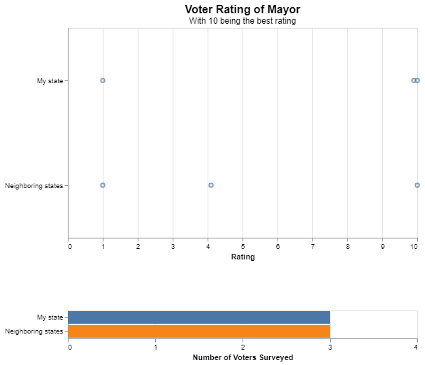

```python
# YOUR ANSWER HERE


strip = alt.Chart(ratings_df, title=alt.TitleParams(text='Voter Rating of Mayor', fontSize=16, subtitle='With 10 being the best rating')).mark_point().encode(
    alt.X('the value', title='Rating'),
    alt.Y('where', title=None)
).properties(height = 300, width = 500)

alt.VConcatChart(ratings_df, vconcat=(strip, bar), spacing=70)
```

### Question 5 (Optional) rubric={viz:0.5,reasoning:0.5}

#### R or Python

Pick a existing ggplot or Altair chart and improve at least 3 different communication related aspects of this plot that we have discussed in lectures. In addition, show your proficiency in reading the documentation and looking for help online, by finding one communication related parameter that we have not discussed in lectures and use it to improve the visuals of the plot (it is also ok to use an option that we haven’t discussed of a parameter that we have discussed).

1. Paste in the code of the existing plot you picked and run it so that we can see what the original looked like. Include the URL to the original plot as a comment in the code cell.
   - You can take any plot you want! As long as you can find the source code and paste it here (and it is not copyright protected). There are suggestions for [ggplot here](https://www.r-graph-gallery.com/) and [Altair here](https://altair-viz.github.io/gallery/index.html).
2. In a new cell, make your modifications and plot the improved chart.
3. Briefly describe the changes you made and why they make this plot more suitable for communication. Explicitly mention which new parameter/option you picked that we have not discussed before and why you picked it.

```python
# YOU ANSWER TO #1 GOES HERE, REMEBER THE URL.
```

```python
# YOU ANSWER TO #2 GOES HERE
```

Ready to submit? I hope you had a favorable view of my data interpretations or there might be trouble coming your way in lab4...

# Submission to Canvas

When you are ready to submit your assignment do the following:

1. Run all cells in your notebook to make sure there are no errors by doing `Kernel -> Restart Kernel and Run All Cells...`
2. Commit and push all your work (including the .ipynb file) to GitHub.
3. Submit a link to your repo on Canvas (this has to be done only once per group).